# biomethods_finalproject

Xiao Shi

December 5, 2018

read in the data

```r
cancer = read.csv("cancer.csv") %>%
  janitor::clean_names()
summary(cancer)
```

```
##  avg_ann_count     avg_deaths_per_year target_death_rate incidence_rate
##  Min.   :    6.0   Min.   :    3       Min.   : 59.7     Min.   : 201.3
##  1st Qu.:   76.0   1st Qu.:   28       1st Qu.:161.2     1st Qu.: 420.3
##  Median :  171.0   Median :   61       Median :178.1     Median : 453.5
##  Mean   :  606.3   Mean   :  186       Mean   :178.7     Mean   : 448.3
##  3rd Qu.:  518.0   3rd Qu.:  149       3rd Qu.:195.2     3rd Qu.: 480.9
##  Max.   :38150.0   Max.   :14010       Max.   :362.8     Max.   :1206.9
##
##    med_income      pop_est2015       poverty_percent study_per_cap
##  Min.   : 22640   Min.   :     827   Min.   : 3.20   Min.   :   0.00
##  1st Qu.: 38883   1st Qu.:   11684   1st Qu.:12.15   1st Qu.:   0.00
##  Median : 45207   Median :   26643   Median :15.90   Median :   0.00
##  Mean   : 47063   Mean   :  102637   Mean   :16.88   Mean   : 155.40
##  3rd Qu.: 52492   3rd Qu.:   68671   3rd Qu.:20.40   3rd Qu.:  83.65
##  Max.   :125635   Max.   :10170292   Max.   :47.40   Max.   :9762.31
##
##               binned_inc     median_age     median_age_male
##  (45201, 48021.6]  : 306   Min.   : 22.30   Min.   :22.40
##  (54545.6, 61494.5]: 306   1st Qu.: 37.70   1st Qu.:36.35
##  [22640, 34218.1]  : 306   Median : 41.00   Median :39.60
##  (42724.4, 45201]  : 305   Mean   : 45.27   Mean   :39.57
##  (48021.6, 51046.4]: 305   3rd Qu.: 44.00   3rd Qu.:42.50
##  (51046.4, 54545.6]: 305   Max.   :624.00   Max.   :64.70
##  (Other)           :1214
##  median_age_female                            geography
##  Min.   :22.30     Abbeville County, South Carolina:   1
##  1st Qu.:39.10     Acadia Parish, Louisiana        :   1
##  Median :42.40     Accomack County, Virginia       :   1
##  Mean   :42.15     Ada County, Idaho               :   1
##  3rd Qu.:45.30     Adair County, Iowa              :   1
##  Max.   :65.70     Adair County, Kentucky          :   1
##                    (Other)                         :3041
##  avg_household_size percent_married pct_no_hs18_24   pct_hs18_24
##  Min.   :0.0221     Min.   :23.10   Min.   : 0.00   Min.   : 0.0
##  1st Qu.:2.3700     1st Qu.:47.75   1st Qu.:12.80   1st Qu.:29.2
##  Median :2.5000     Median :52.40   Median :17.10   Median :34.7
##  Mean   :2.4797     Mean   :51.77   Mean   :18.22   Mean   :35.0
##  3rd Qu.:2.6300     3rd Qu.:56.40   3rd Qu.:22.70   3rd Qu.:40.7
##  Max.   :3.9700     Max.   :72.50   Max.   :64.10   Max.   :72.5
##
```

[output cut: 33 more lines]

```
##  Min.   : 0.0000   Min.   : 0.0000   Min.   :22.99
##  1st Qu.: 0.2542   1st Qu.: 0.2952   1st Qu.:47.76
##  Median : 0.5498   Median : 0.8262   Median :51.67
##  Mean   : 1.2540   Mean   : 1.9835   Mean   :51.24
##  3rd Qu.: 1.2210   3rd Qu.: 2.1780   3rd Qu.:55.40
##  Max.   :42.6194   Max.   :41.9303   Max.   :78.08
##
##    birth_rate
##  Min.   : 0.000
##  1st Qu.: 4.521
##  Median : 5.381
##  Mean   : 5.640
##  3rd Qu.: 6.494
##  Max.   :21.326
##
```

divide into states/ into Bureau of Economic Analysis regions

```r
cancer$states = sub('.*,\\s*', '', cancer$geography)

cancer$econ_region = ifelse(cancer$states == "Connecticut", "New England", NA)
cancer$econ_region = ifelse(cancer$states == "Maine", "New England", cancer$econ_region)
cancer$econ_region = ifelse(cancer$states == "Massachusetts", "New England", cancer$econ_region)
cancer$econ_region = ifelse(cancer$states == "New Hampshire", "New England", cancer$econ_region)
cancer$econ_region = ifelse(cancer$states == "Rhode Island", "New England", cancer$econ_region)
cancer$econ_region = ifelse(cancer$states == "Vermont", "New England", cancer$econ_region)
cancer$econ_region = ifelse(cancer$states == "Delaware", "Mideast", cancer$econ_region)
cancer$econ_region = ifelse(cancer$states == "District of Columbia", "Mideast", cancer$econ_region)
cancer$econ_region = ifelse(cancer$states == "Maryland", "Mideast", cancer$econ_region)
cancer$econ_region = ifelse(cancer$states == "New Jersey", "Mideast", cancer$econ_region)
cancer$econ_region = ifelse(cancer$states == "New York", "Mideast", cancer$econ_region)
cancer$econ_region = ifelse(cancer$states == "Pennsylvania", "Mideast", cancer$econ_region)
cancer$econ_region = ifelse(cancer$states == "Illinois", "Great Lakes", cancer$econ_region)
cancer$econ_region = ifelse(cancer$states == "Indiana", "Great Lakes", cancer$econ_region)
cancer$econ_region = ifelse(cancer$states == "Ohio", "Great Lakes", cancer$econ_region)
cancer$econ_region = ifelse(cancer$states == "Michigan", "Great Lakes", cancer$econ_region)
cancer$econ_region = ifelse(cancer$states == "Wisconsin", "Great Lakes", cancer$econ_region)
cancer$econ_region = ifelse(cancer$states == "Iowa", "Plains", cancer$econ_region)
cancer$econ_region = ifelse(cancer$states == "Kansas", "Plains", cancer$econ_region)
cancer$econ_region = ifelse(cancer$states == "Minnesota", "Plains", cancer$econ_region)
cancer$econ_region = ifelse(cancer$states == "Missouri", "Plains", cancer$econ_region)
cancer$econ_region = ifelse(cancer$states == "Nebraska", "Plains", cancer$econ_region)
cancer$econ_region = ifelse(cancer$states == "North Dakota", "Plains", cancer$econ_region)
cancer$econ_region = ifelse(cancer$states == "South Dakota", "Plains", cancer$econ_region)
cancer$econ_region = ifelse(cancer$states == "Alabama", "Southeast", cancer$econ_region)
cancer$econ_region = ifelse(cancer$states == "Arkansas", "Southeast", cancer$econ_region)
cancer$econ_region = ifelse(cancer$states == "Georgia", "Southeast", cancer$econ_region)
cancer$econ_region = ifelse(cancer$states == "Florida", "Southeast", cancer$econ_region)
cancer$econ_region = ifelse(cancer$states == "Kentucky", "Southeast", cancer$econ_region)
cancer$econ_region = ifelse(cancer$states == "Louisiana", "Southeast", cancer$econ_region)
cancer$econ_region = ifelse(cancer$states == "Mississippi", "Southeast", cancer$econ_region)
cancer$econ_region = ifelse(cancer$states == "North Carolina", "Southeast", cancer$econ_region)
cancer$econ_region = ifelse(cancer$states == "South Carolina", "Southeast", cancer$econ_region)
cancer$econ_region = ifelse(cancer$states == "Tennessee", "Southeast", cancer$econ_region)
cancer$econ_region = ifelse(cancer$states == "Virginia", "Southeast", cancer$econ_region)
cancer$econ_region = ifelse(cancer$states == "West Virginia", "Southeast", cancer$econ_region)
cancer$econ_region = ifelse(cancer$states == "Oklahoma", "Southwest", cancer$econ_region)
cancer$econ_region = ifelse(cancer$states == "New Mexico", "Southwest", cancer$econ_region)
cancer$econ_region = ifelse(cancer$states == "Arizona", "Southwest", cancer$econ_region)
cancer$econ_region = ifelse(cancer$states == "Texas", "Southwest", cancer$econ_region)
cancer$econ_region = ifelse(cancer$states == "Colorado", "Rocky Mountain", cancer$econ_region)
cancer$econ_region = ifelse(cancer$states == "Idaho", "Rocky Mountain", cancer$econ_region)
cancer$econ_region = ifelse(cancer$states == "Montana", "Rocky Mountain", cancer$econ_region)
cancer$econ_region = ifelse(cancer$states == "Utah", "Rocky Mountain", cancer$econ_region)
cancer$econ_region = ifelse(cancer$states == "Wyoming", "Rocky Mountain", cancer$econ_region)
cancer$econ_region = ifelse(cancer$states == "Alaska", "Far West", cancer$econ_region)
cancer$econ_region = ifelse(cancer$states == "California", "Far West", cancer$econ_region)
cancer$econ_region = ifelse(cancer$states == "Hawaii", "Far West", cancer$econ_region)
cancer$econ_region = ifelse(cancer$states == "Nevada", "Far West", cancer$econ_region)
cancer$econ_region = ifelse(cancer$states == "Oregon", "Far West", cancer$econ_region)
cancer$econ_region = ifelse(cancer$states == "Washington", "Far West", cancer$econ_region)
```

```r
cancer %>%
  group_by(econ_region) %>%
  summarise(mean_death_rate = mean(target_death_rate)) %>%
  knitr::kable()
```

| econ_region | mean_death_rate |
| --- | --- |
| Far West | 167.8649 |
| Great Lakes | 182.1672 |
| Mideast | 173.5433 |
| New England | 171.6716 |
| Plains | 168.8654 |
| Rocky Mountain | 150.6255 |
| Southeast | 192.7818 |
| Southwest | 174.0829 |

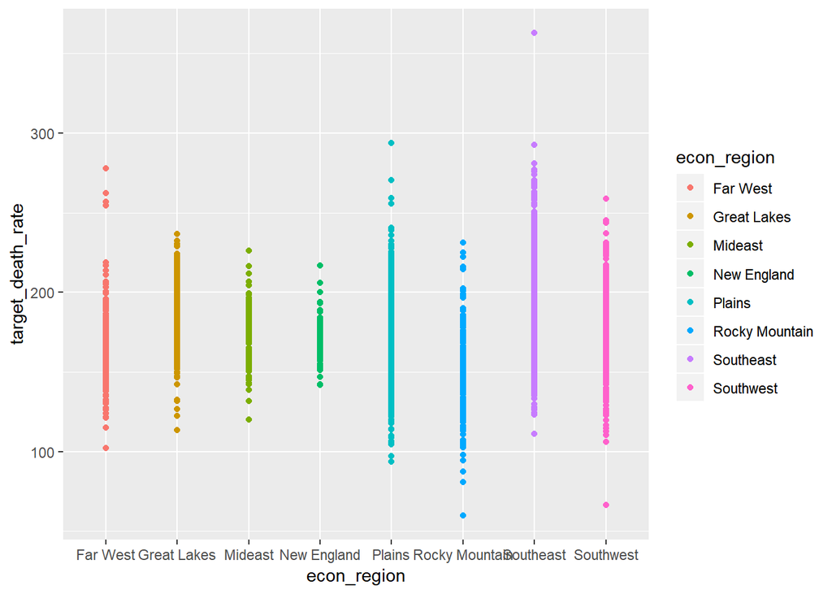

```r
ggplot() +
  geom_point(aes(x = econ_region, y = target_death_rate, color = econ_region), data = cancer)
```

Variable selection based on the following literature:

“It’s encouraging to see progress in decreasing death rates for many types of cancer,” said Betsy A. Kohler, executive director, NAACCR. “Yet the fact that death rates from several cancers are still on the rise means we need to keep working to find strategies to encourage prevention and continue to make improvements in screening and treatment.” [3] The above paragraph demonstrated the fact that some cancer see decreasing death rates while others increased.

Factors such as Age, Alcohol, Cancer-Causing Substances, Chronic Inflammation, Diet, Hormones, Immunosuppression, Infectious Agents, Obesity, Radiation, Sunlight, Tobacco are the most-studied known or suspected risk factors for cancer. [4]

including income level“Cancer prevention requires smoking cessation, increased ingestion of fruits and vegetables, moderate use of alcohol, caloric restriction, exercise, avoidance of direct exposure to sunlight, minimal meat consumption, use of whole grains, use of vaccinations, and regular check-ups” [5]

including `marriage status`: “Extensive research has demonstrated that marriage and parenting are associated with lower testosterone levels in men, however, very little is known about associations with hormone concentrations in women. Here, we examine estradiol and progesterone concentrations in relation to marriage and motherhood in naturally cycling, reproductive age women.” [6] Reference: 1. https://www.cancer.gov/about-cancer/understanding/disparities 2. https://en.wikipedia.org/wiki/List_of_regions_of_the_United_States 3. https://www.cancer.gov/news-events/press-releases/2018/annual-report-nation-2018 4. https://www.cancer.gov/about-cancer/causes-prevention/risk 5. https://www.ncbi.nlm.nih.gov/pmc/articles/PMC2515569/ 6. https://www.ncbi.nlm.nih.gov/pmc/articles/PMC5501487/